# Predicting Customer Churn

#### Checking whether there's too much dependence on certain features

We'll compare a few important features : NumOfProducts, IsActiveMember, Age, Balance

```python
df_ea.NumOfProducts.value_counts(normalize=True).sort_index()
low_recall.NumOfProducts.value_counts(normalize=True).sort_index()
low_prec.NumOfProducts.value_counts(normalize=True).sort_index()
```

```
1    0.506481
2    0.467593
3    0.020370
4    0.005556
Name: NumOfProducts, dtype: float64
```

```
1    0.682927
2    0.317073
Name: NumOfProducts, dtype: float64
```

```
1    0.843137
2    0.127451
3    0.029412
Name: NumOfProducts, dtype: float64
```

```python
df_ea.IsActiveMember.value_counts(normalize=True).sort_index()
low_recall.IsActiveMember.value_counts(normalize=True).sort_index()
low_prec.IsActiveMember.value_counts(normalize=True).sort_index()
```

```
0    0.481481
1    0.518519
Name: IsActiveMember, dtype: float64
```

```
0    0.573171
1    0.426829
Name: IsActiveMember, dtype: float64
```

```
0    0.627451
1    0.372549
Name: IsActiveMember, dtype: float64
```

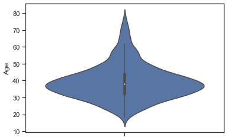

```python
sns.violinplot(y = df_ea.Age);
```

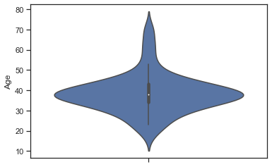

```python
sns.violinplot(y = low_recall.Age);
```

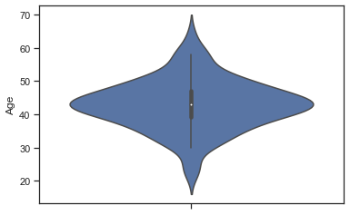

```python
sns.violinplot(y = low_prec.Age);
```

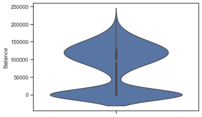

```python
sns.violinplot(y = df_ea.Balance);
```

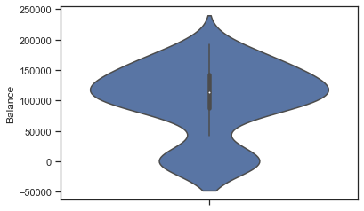

```python
sns.violinplot(y = low_recall.Balance);
```

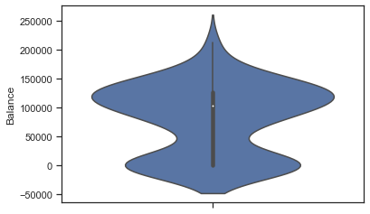

```python
sns.violinplot(y = low_prec.Balance);
```

### Train final, best model ; Save model and its parameters

```python
from sklearn.pipeline import Pipeline
from lightgbm import LGBMClassifier
from sklearn.metrics import roc_auc_score, f1_score, recall_score, confusion_matrix, classification_report
import joblib
```

```python
## Re-defining X_train and X_val to consider original unscaled continuous features. y_train and y_val remain unaffected
X_train = df_train.drop(columns = ['Exited'], axis = 1)
X_val = df_val.drop(columns = ['Exited'], axis = 1)

X_train.shape, y_train.shape
X_val.shape, y_val.shape
```

```
((7920, 15), (7920,))
```

```
((1080, 15), (1080,))
```

```python
best_f1_lgb = LGBMClassifier(boosting_type = 'dart', class_weight = {0: 1, 1: 3.0}, min_child_samples = 20, n_jobs = - 1
                     , importance_type = 'gain', max_depth = 6, num_leaves = 63, colsample_bytree = 0.6, learning_rate = 0.1
                     , n_estimators = 201, reg_alpha = 1, reg_lambda = 1)
```

```python
best_recall_lgb = LGBMClassifier(boosting_type='dart', num_leaves=31, max_depth= 6, learning_rate=0.1, n_estimators = 21
                                 , class_weight= {0: 1, 1: 3.93}, min_child_samples=2, colsample_bytree=0.6, reg_alpha=0.3
                                 , reg_lambda=1.0, n_jobs=- 1, importance_type = 'gain')
```

```python
model = Pipeline(steps = [('categorical_encoding', CategoricalEncoder()),
                          ('add_new_features', AddFeatures()),
                          ('classifier', best_f1_lgb)
                         ])
```

```python
## Fitting final model on train dataset
model.fit(X_train, y_train)
```

```
Pipeline(steps=[('categorical_encoding',
                 CategoricalEncoder(cols=[], lcols=[], ohecols=[], tcols=[])),
                ('add_new_features', AddFeatures()),
                ('classifier',
                 LGBMClassifier(boosting_type='dart',
                                class_weight={0: 1, 1: 3.0},
                                colsample_bytree=0.6, importance_type='gain',
                                max_depth=6, n_estimators=201, num_leaves=63,
                                reg_alpha=1, reg_lambda=1))])
```

```python
# Predict target probabilities
val_probs = model.predict_proba(X_val)[:,1]

# Predict target values on val data
val_preds = np.where(val_probs > 0.45, 1, 0) # The probability threshold can be tweaked
```

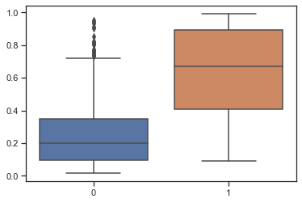

```python
sns.boxplot(y_val.ravel(), val_probs);
```

```python
## Validation metrics
get_metrics(y_val, val_preds)
```

```
ROC_AUC_Score:  0.7784386913910458
Recall Score:  0.7100840336134454

Confusion Matrix
     0    1
0  713  129
1   69  169

Classification Report
              precision    recall  f1-score   support

           0       0.91      0.85      0.88       842
           1       0.57      0.71      0.63       238

    accuracy                           0.82      1080
   macro avg       0.74      0.78      0.75      1080
weighted avg       0.84      0.82      0.82      1080
```

```python
## Save model object
joblib.dump(model, 'final_churn_model_f1_0_45.sav')
```

```
['final_churn_model_f1_0_45.sav']
```

### SHAP

SHAP paper : https://papers.nips.cc/paper/7062-a-unified-approach-to-interpreting-model-predictions.pdf

```python
import shap

shap.initjs()
```

```python
ce = CategoricalEncoder()
af = AddFeatures()

X = ce.fit_transform(X_train, y_train)
X = af.transform(X)
```

```python
X.shape
X.sample(5)
```

```
(7920, 15)
```

|  | CreditScore | Gender | Age | Tenure | Balance | NumOfProducts | HasCrCard | IsActiveMember | EstimatedSalary | country_France | country_Germany | country_Spain | bal_per_product | bal_by_est_salary | tenure_age_ratio |
| --- | --- | --- | --- | --- | --- | --- | --- | --- | --- | --- | --- | --- | --- | --- | --- |
| 7535 | 604 | 1 | 23 | 9 | 124577.33 | 1 | 1 | 1 | 7267.25 | 0.0 | 0.0 | 1.0 | 124577.205423 | 17.142293 | 0.391304 |
| 2493 | 732 | 0 | 69 | 9 | 137453.43 | 1 | 0 | 1 | 110932.24 | 0.0 | 0.0 | 1.0 | 137453.292547 | 1.239076 | 0.130435 |
| 2329 | 576 | 1 | 19 | 6 | 0.00 | 2 | 0 | 0 | 72306.07 | 0.0 | 0.0 | 1.0 | 0.000000 | 0.000000 | 0.315789 |
| 7611 | 651 | 1 | 34 | 2 | 90355.12 | 2 | 0 | 0 | 193597.94 | 0.0 | 1.0 | 0.0 | 45177.537411 | 0.466715 | 0.058824 |
| 3781 | 697 | 0 | 25 | 1 | 0.00 | 2 | 0 | 0 | 87803.32 | 1.0 | 0.0 | 0.0 | 0.000000 | 0.000000 | 0.040000 |

```python
best_f1_lgb.fit(X_train, y_train)
```

```
LGBMClassifier(boosting_type='dart', class_weight={0: 1, 1: 3.0},
               colsample_bytree=0.6, importance_type='gain', max_depth=6,
               n_estimators=201, num_leaves=63, reg_alpha=1, reg_lambda=1)
```

```python
explainer = shap.TreeExplainer(best_f1_lgb)
```

```python
X.head(10)
```

|  | CreditScore | Gender | Age | Tenure | Balance | NumOfProducts | HasCrCard | IsActiveMember | EstimatedSalary | country_France | country_Germany | country_Spain | bal_per_product | bal_by_est_salary | tenure_age_ratio |
| --- | --- | --- | --- | --- | --- | --- | --- | --- | --- | --- | --- | --- | --- | --- | --- |
| 0 | 678 | 1 | 36 | 1 | 117864.85 | 2 | 1 | 0 | 27619.06 | 0.0 | 1.0 | 0.0 | 58932.395534 | 4.267519 | 0.027778 |
| 1 | 613 | 0 | 27 | 5 | 125167.74 | 1 | 1 | 0 | 199104.52 | 1.0 | 0.0 | 0.0 | 125167.614832 | 0.628653 | 0.185185 |
| 2 | 628 | 1 | 45 | 9 | 0.00 | 2 | 1 | 1 | 96862.56 | 1.0 | 0.0 | 0.0 | 0.000000 | 0.000000 | 0.200000 |
| 3 | 513 | 1 | 30 | 5 | 0.00 | 2 | 1 | 0 | 162523.66 | 1.0 | 0.0 | 0.0 | 0.000000 | 0.000000 | 0.166667 |
| 4 | 639 | 1 | 22 | 4 | 0.00 | 2 | 1 | 0 | 28188.96 | 1.0 | 0.0 | 0.0 | 0.000000 | 0.000000 | 0.181818 |
| 5 | 562 | 1 | 30 | 3 | 111099.79 | 2 | 0 | 0 | 140650.19 | 1.0 | 0.0 | 0.0 | 55549.867225 | 0.789901 | 0.100000 |
| 6 | 635 | 1 | 43 | 5 | 78992.75 | 2 | 0 | 0 | 153265.31 | 0.0 | 1.0 | 0.0 | 39496.355252 | 0.515399 | 0.116279 |
| 7 | 705 | 1 | 33 | 7 | 68423.89 | 1 | 1 | 1 | 64872.55 | 0.0 | 0.0 | 1.0 | 68423.821576 | 1.054743 | 0.212121 |
| 8 | 694 | 1 | 42 | 8 | 133767.19 | 1 | 1 | 0 | 36405.21 | 1.0 | 0.0 | 0.0 | 133767.056233 | 3.674397 | 0.190476 |
| 9 | 711 | 1 | 26 | 9 | 128793.63 | 1 | 1 | 0 | 19262.05 | 0.0 | 1.0 | 0.0 | 128793.501206 | 6.686393 | 0.346154 |

```python
row_num = 7
shap_vals = explainer.shap_values(X.iloc[row_num].values.reshape(1,-1))
```

```python
#base value
explainer.expected_value
```

```
[0.9585005527884033, -0.9585005527884033]
```

```python
## Explain single prediction
shap.force_plot(explainer.expected_value[1], shap_vals[1], X.iloc[row_num], link = 'logit')
```

```python
## Check probability predictions through the model
pred_probs = best_f1_lgb.predict_proba(X)[:,1]
pred_probs[row_num]
```

```
0.34128442893776556
```

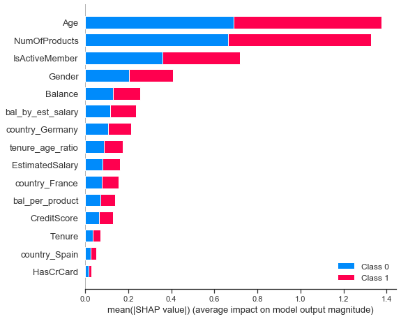

```python
## Explain global patterns/ summary stats
shap_values = explainer.shap_values(X)
shap.summary_plot(shap_values, X)
```

### Load saved model and make predictions on unseen/future data

Here, we'll use df_test as the unseen, future data

```python
import joblib
```

```python
## Load model object
model = joblib.load('final_churn_model_f1_0_45.sav')
```

```python
X_test = df_test.drop(columns = ['Exited'], axis = 1)
X_test.shape
y_test.shape
```

```
(1000, 15)
```

```
(1000,)
```

```python
## Predict target probabilities
test_probs = model.predict_proba(X_test)[:,1]
```

```python
## Predict target values on test data
test_preds = np.where(test_probs > 0.45, 1, 0) # Flexibility to tweak the probability threshold
#test_preds = model.predict(X_test)
```

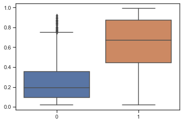

```python
sns.boxplot(y_test.ravel(), test_probs);
```

```python
## Test set metrics
get_metrics(y_test, test_preds)
```

```
ROC_AUC_Score:  0.79323578330173
Recall Score:  0.743455497382199

Confusion Matrix
     0    1
0  682  127
1   49  142

Classification Report
              precision    recall  f1-score   support

           0       0.93      0.84      0.89       809
           1       0.53      0.74      0.62       191

    accuracy                           0.82      1000
   macro avg       0.73      0.79      0.75      1000
weighted avg       0.86      0.82      0.83      1000
```

```python
## Adding predictions and their probabilities in the original test dataframe
test = df_test.copy()
test['predictions'] = test_preds
test['pred_probabilities'] = test_probs
```

```python
test.sample(10)
```

|  | CreditScore | Gender | Age | Tenure | Balance | NumOfProducts | HasCrCard | IsActiveMember | EstimatedSalary | Exited | country_France | country_Germany | country_Spain | bal_per_product | bal_by_est_salary | tenure_age_ratio | predictions | pred_probabilities |
| --- | --- | --- | --- | --- | --- | --- | --- | --- | --- | --- | --- | --- | --- | --- | --- | --- | --- | --- |
| 504 | 420 | 0 | 34 | 1 | 135549.90 | 1 | 0 | 0 | 149471.13 | 1 | 0.0 | 1.0 | 0.0 | 135549.764450 | 0.906863 | 0.029412 | 1 | 0.489977 |
| 747 | 671 | 1 | 27 | 5 | 0.00 | 2 | 0 | 0 | 120893.07 | 0 | 1.0 | 0.0 | 0.0 | 0.000000 | 0.000000 | 0.185185 | 0 | 0.039198 |
| 678 | 537 | 1 | 84 | 8 | 92242.34 | 1 | 1 | 1 | 186235.98 | 0 | 0.0 | 1.0 | 0.0 | 92242.247758 | 0.495298 | 0.095238 | 0 | 0.248468 |
| 871 | 602 | 1 | 29 | 5 | 103907.28 | 1 | 1 | 0 | 161229.84 | 0 | 0.0 | 0.0 | 1.0 | 103907.176093 | 0.644467 | 0.172414 | 0 | 0.201751 |
| 295 | 637 | 0 | 39 | 3 | 109698.41 | 1 | 1 | 1 | 88391.29 | 1 | 0.0 | 1.0 | 0.0 | 109698.300302 | 1.241055 | 0.076923 | 1 | 0.520405 |
| 859 | 611 | 1 | 68 | 5 | 82547.11 | 2 | 1 | 1 | 146448.01 | 0 | 1.0 | 0.0 | 0.0 | 41273.534363 | 0.563662 | 0.073529 | 0 | 0.083983 |
| 707 | 509 | 0 | 29 | 0 | 107712.57 | 2 | 1 | 1 | 92898.17 | 0 | 0.0 | 1.0 | 0.0 | 53856.258072 | 1.159469 | 0.000000 | 0 | 0.160579 |
| 141 | 584 | 0 | 31 | 6 | 152622.34 | 1 | 1 | 0 | 99298.80 | 0 | 0.0 | 1.0 | 0.0 | 152622.187378 | 1.537001 | 0.193548 | 0 | 0.357519 |
| 153 | 691 | 0 | 33 | 6 | 0.00 | 2 | 1 | 0 | 164074.89 | 0 | 1.0 | 0.0 | 0.0 | 0.000000 | 0.000000 | 0.181818 | 0 | 0.077827 |
| 372 | 510 | 1 | 63 | 8 | 0.00 | 2 | 1 | 1 | 115291.86 | 0 | 1.0 | 0.0 | 0.0 | 0.000000 | 0.000000 | 0.126984 | 0 | 0.132348 |

#### Creating a list of customers who are the most likely to churn

Listing customers who have a churn probability higher than 70%. These are the ones who can be targeted immediately

```python
high_churn_list = test[test.pred_probabilities > 0.7].sort_values(by = ['pred_probabilities'], ascending = False
                                                                 ).reset_index().drop(columns = ['index', 'Exited', 'predictions'], axis = 1)
```

```python
high_churn_list.shape
high_churn_list.head()
```

```
(115, 16)
```

|  | CreditScore | Gender | Age | Tenure | Balance | NumOfProducts | HasCrCard | IsActiveMember | EstimatedSalary | country_France | country_Germany | country_Spain | bal_per_product | bal_by_est_salary | tenure_age_ratio | pred_probabilities |
| --- | --- | --- | --- | --- | --- | --- | --- | --- | --- | --- | --- | --- | --- | --- | --- | --- |
| 0 | 546 | 0 | 58 | 3 | 106458.31 | 4 | 1 | 0 | 128881.87 | 0.0 | 1.0 | 0.0 | 26614.570846 | 0.826015 | 0.051724 | 0.993276 |
| 1 | 665 | 0 | 43 | 2 | 116322.27 | 4 | 1 | 0 | 35640.12 | 0.0 | 1.0 | 0.0 | 29080.560230 | 3.263801 | 0.046512 | 0.983216 |
| 2 | 479 | 1 | 51 | 1 | 107714.74 | 3 | 1 | 0 | 86128.21 | 0.0 | 1.0 | 0.0 | 35904.901365 | 1.250633 | 0.019608 | 0.983053 |
| 3 | 515 | 1 | 45 | 7 | 120961.50 | 3 | 1 | 1 | 39288.11 | 0.0 | 1.0 | 0.0 | 40320.486560 | 3.078832 | 0.155556 | 0.981261 |
| 4 | 697 | 0 | 49 | 7 | 195238.29 | 4 | 0 | 1 | 131083.56 | 1.0 | 0.0 | 0.0 | 48809.560298 | 1.489419 | 0.142857 | 0.975912 |

```python
high_churn_list.to_csv('high_churn_list.csv', index = False)
```

#### Feature-based user segments from the above list

Based on business requirements, a prioritization matrix can be defined, wherein certain segments of customers are targeted first. These segments can be defined based on insights through data or the business teams' requirements. E.g. Active male members with a credit card from Germany can be prioritized first if there is a good ROI from them.